# CodesRUs_midterm

March 9, 2022

# R Markdown - Exploratory Data Analysis of Soccer Event Data Codes

**SMART Question:** Based on the matches played during the 2017/2018 season for Europe’s top five leagues, the 2016 European Championship, and the 2018 World Cup, which match variables (ex: shot location, assist location, assist duration, etc…) result in the highest probability of a shot on goal being successful, result in a goal?

## Importing Data:

**Dataset:** The dataset contains all matches played in Europe’s top five leagues during the 2017/2018 season (380 matches per league for a total of 1900 matches, producing 643,149 match events), the 2016 European Championship (51 matches, producing 78,139 match events), and the 2018 World Cup (64 matches, 101,758 match events). It was obtained from the work posted by Luca Pappalardo on Figshare.

```r
#Load Event data from each competition as a dataframe
england<-data.frame(read.csv('./datasets/events_England_new.csv'))
england$competition <- "England"

italy<-data.frame(read.csv('./datasets/events_Italy_new.csv'))
italy$competition <- "Italy"

germany<-data.frame(read.csv('./datasets/events_Germany_new.csv'))
germany$competition <- "Germany"

france<-data.frame(read.csv('./datasets/events_France_new.csv'))
france$competition <- "France"

spain<-data.frame(read.csv('./datasets/events_Spain_new.csv'))
spain$competition <- "Spain"

european<-data.frame(read.csv('./datasets/events_European_Championship_new.csv'))
european$competition <- "European"

worldcup<-data.frame(read.csv('./datasets/events_World_Cup_new.csv'))
worldcup$competition <- "World Cup"

#Append dataframes into a single dataframe from which to draw.
event_data<-rbind(england, italy, germany, france, spain, european, worldcup)
#str(event_data)
xkabledplyhead(event_data)
```

Head

| X | Event.Name | Subevent.Name | Match.Period | Event.Time | x.Start | y.Start | x.End | y.End | Player | Team.Name | Match.Date | Tag.1 | Tag.2 | Tag.3 | Tag.4 | Tag.5 | Tag.6 | competition |
| --- | --- | --- | --- | --- | --- | --- | --- | --- | --- | --- | --- | --- | --- | --- | --- | --- | --- | --- |
| 0 | Pass | Simple pass | 1H | 2.76 | 49 | 49 | 31 | 78 | Lacazette | Arsenal | 2017-08-11 18:45:00 | Accurate |  |  |  |  |  | England |
| 1 | Pass | High pass | 1H | 4.95 | 31 | 78 | 51 | 75 | Holding | Arsenal | 2017-08-11 18:45:00 | Accurate |  |  |  |  |  | England |
| 2 | Pass | Head pass | 1H | 6.54 | 51 | 75 | 35 | 71 | 0d6zil | Arsenal | 2017-08-11 18:45:00 | Accurate |  |  |  |  |  | England |
| 3 | Pass | Head pass | 1H | 8.14 | 35 | 71 | 41 | 95 | Elsayed Elneny | Arsenal | 2017-08-11 18:45:00 | Accurate |  |  |  |  |  | England |
| 4 | Pass | Simple pass | 1H | 10.30 | 41 | 95 | 72 | 88 | Beller0edn Moruno | Arsenal | 2017-08-11 18:45:00 | Accurate |  |  |  |  |  | England |

```r
#tail(event_data)
```

## Cleaning Data:

X and Y coordinates had been imported as characters. We therefore converted them to numeric to allow us to work with them. Event Name and Subevent Name are have also been converted to factor.

```r
#convert x and y coordinate columns from characters to integer values
event_data$x.End <- as.numeric(event_data$x.End)
event_data$y.End <- as.numeric(event_data$y.End)

event_data$x.Start <- as.numeric(event_data$x.Start)
event_data$y.Start <- as.numeric(event_data$y.Start)

#convert event, subevent, tags, players, team labels, etc... to factors
event_data$Event.Name=as.factor(event_data$Event.Name)
event_data$Subevent.Name=as.factor(event_data$Subevent.Name)
event_data$Match.Period=as.factor(event_data$Match.Period)
event_data$Match.Date=as.factor(event_data$Match.Date)
event_data$Player=as.factor(event_data$Player)
event_data$Team.Name=as.factor(event_data$Team.Name)
event_data$Tag.1=as.factor(event_data$Tag.1)
event_data$Tag.2=as.factor(event_data$Tag.2)
event_data$Tag.3=as.factor(event_data$Tag.3)
event_data$Tag.4=as.factor(event_data$Tag.4)
event_data$Tag.5=as.factor(event_data$Tag.5)
event_data$Tag.6=as.factor(event_data$Tag.6)

str(event_data)
```

## Calculating and Adding Event Distance Variable:

One variable we are interested in looking at is the distance of assists and key passes and whether this plays a role in the success of the pass and whether it results in a successful shot on goal or not. We have to calculate distance for each event using the x,y-coordinates given in the data set.

```r
event_data<-event_data %>% mutate(dist = sqrt((x.End-x.Start)^2+(y.End-y.Start)^2))

event_data$dist <- as.numeric(event_data$dist)

summary(event_data$dist)
str(event_data)
```

## Subsetting Data:

Separate data frames are created for each of the following events of interest:  
1. Shots: unsuccessful shots on goal  
2. goals: successful shots on goal  
3. assists: pass leading to a goal  
4. key passes: pass leading to unsuccessful scoring opportunity

```r
#Collect shots, goals, assists, and key passes into their own dataframes
shots<-subset(event_data, Event.Name=='Shot')
shots<-subset(shots, Tag.1!='Goal')
goals<-subset(event_data, Tag.1=='Goal')
assists<-subset(event_data, Tag.1=='Assist')
key_passes<-subset(event_data, Tag.1=='Key pass')

head(shots)
head(goals)
head(assists)
head(key_passes)
```

## Checking Each Variable for Outliers:

We checked each variable of interest for outliers and removed them. **Figure 1.**, below, shows the outlier check for the assist distance variable. Many outliers are seen at the high end of the histogram resulting in a skewed distribution. This is also seen in both the q-q plot and the boxplot. After removing the outliers, a better normal distribution is seen.

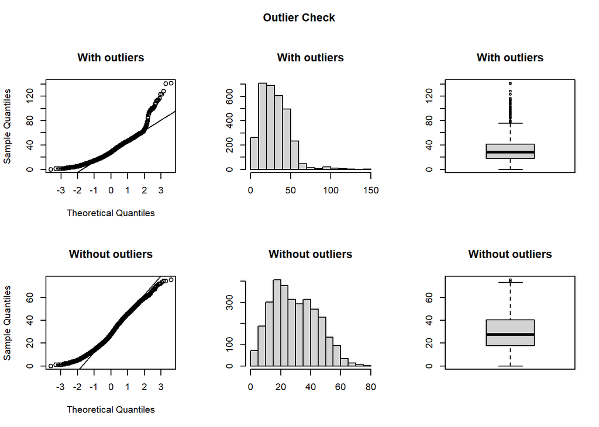

```r
show_all_plots=FALSE

assists_clean<-outlierKD2(assists, dist, rm=TRUE, boxplt = TRUE, histogram = TRUE, qqplt = TRUE)
```

```r
assists_clean<-na.omit(assists_clean)

assists_clean_x<-outlierKD2(assists, x.Start, rm=TRUE,
                            boxplt = show_all_plots,
                            histogram = show_all_plots,
                            qqplt = show_all_plots)
assists_clean_x<-na.omit(assists_clean_x)

assists_clean_y<-outlierKD2(assists, y.Start, rm=TRUE,
                            boxplt = show_all_plots,
                            histogram = show_all_plots,
                            qqplt = show_all_plots)
assists_clean_y<-na.omit(assists_clean_y)

key_passes_clean<-outlierKD2(key_passes, dist, rm=TRUE,
                            boxplt = show_all_plots,
                            histogram = show_all_plots,
                            qqplt = show_all_plots)
key_passes_clean<-na.omit(key_passes_clean)

key_passes_clean_x<-outlierKD2(key_passes, x.Start, rm=TRUE,
                            boxplt = show_all_plots,
                            histogram = show_all_plots,
                            qqplt = show_all_plots)
key_passes_clean_x<-na.omit(key_passes_clean_x)

key_passes_clean_y<-outlierKD2(key_passes, y.Start, rm=TRUE,
                            boxplt = show_all_plots,
                            histogram = show_all_plots,
                            qqplt = show_all_plots)
key_passes_clean_y<-na.omit(key_passes_clean_y)

shots_clean<-outlierKD2(shots, x.Start, rm=TRUE,
                            boxplt = show_all_plots,
                            histogram = show_all_plots,
                            qqplt = show_all_plots)
shots_clean<-na.omit(shots_clean)

goals_clean<-outlierKD2(goals, x.Start, rm=TRUE,
                            boxplt = show_all_plots,
                            histogram = show_all_plots,
                            qqplt = show_all_plots)
goals_clean<-na.omit(goals_clean)
```

**Figure 1.** Outlier check for assist distance variable.

Quick visual of the field: Plot start position and distance of each event.

```r
#Shots
jpeg(file="shots_start.jpeg")
plot(shots_clean$x.Start,shots_clean$y.Start,main='Start Position of Shots', xlab = 'x.Start', ylab = 'y.Start')
dev.off()

jpeg(file="shots_dist.jpeg")
hist(shots_clean$dist, main='Distance of Shots', xlab = 'Shot Distance')
dev.off()

#Goals
jpeg(file="goals_start.jpeg")
plot(goals_clean$x.Start,goals_clean$y.Start,main='Start Position of Goals', xlab = 'x.Start', ylab = 'y.Start')
dev.off()

jpeg(file="goals_dist.jpeg")
hist(goals_clean$dist, main='Distance of Shots Leading to Goals', xlab = 'Shot Distance')
dev.off()

#Assists

jpeg(file="assists_start.jpeg")
plot(assists_clean$x.Start,assists_clean$y.Start,main='Start Position of Assists', xlab = 'x.Start', ylab = 'y.Start')
dev.off()

jpeg(file="assists_dist.jpeg")
hist(assists_clean$dist, main='Distance of Assists', xlab = 'Shot Distance')
dev.off()

#Key Passes

jpeg(file="keypass_start.jpeg")
plot(key_passes_clean$x.Start,key_passes_clean$y.Start,main='Start Position of Key Passes', xlab = 'x.Start', ylab = 'y.Start')
dev.off()

jpeg(file="keypass_dist.jpeg")
hist(key_passes_clean$dist, main='Distance of Key Passes', xlab = 'Shot Distance')
dev.off()
```

Visualize distributions of variables of interest.

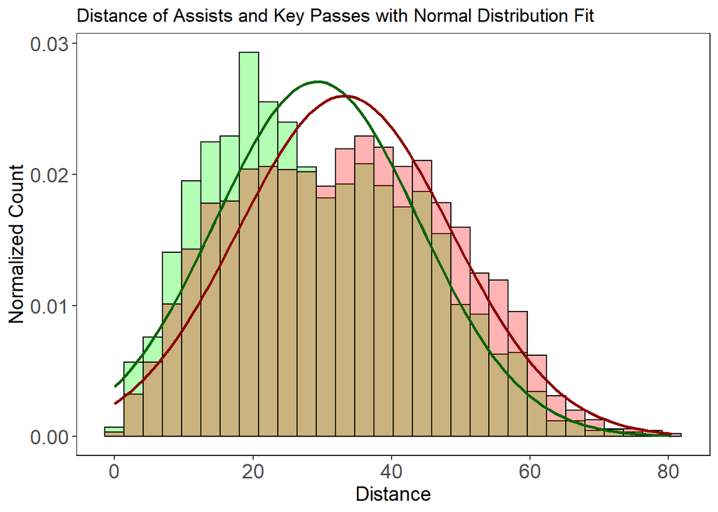

```r
#Histograms of Assist and Key Pass Distance

ggplot()+
  geom_histogram(data=assists_clean, aes(x=dist, y=..density..), color='Black', fill='Green', alpha=0.3)+

  geom_histogram(data=key_passes_clean, aes(x=dist, y=..density..), color='Black', fill='Red', alpha=0.3)+

  stat_function(fun = dnorm, args = list(mean = mean(assists_clean$dist), sd = sd(assists_clean$dist)), color='dark green', fill='green', size=1)+

  stat_function(fun = dnorm, args = list(mean = mean(key_passes_clean$dist), sd = sd(key_passes_clean$dist)), color='dark red', fill='green', size=1)+

  labs(title="Distance of Assists and Key Passes with Normal Distribution Fit", x="Distance", y="Normalized Count")+

  scale_color_manual(name='Key',values=c('Green', 'Red'), labels=c('Assists','Key Passes'))+
  theme(panel.background = element_blank(),
        panel.border=element_rect(color='black', fill=NA),
        axis.text = element_text(size=14),
        axis.title = element_text(size=14))
```

```r
ggsave("assist_keypass_dist.jpeg")
```

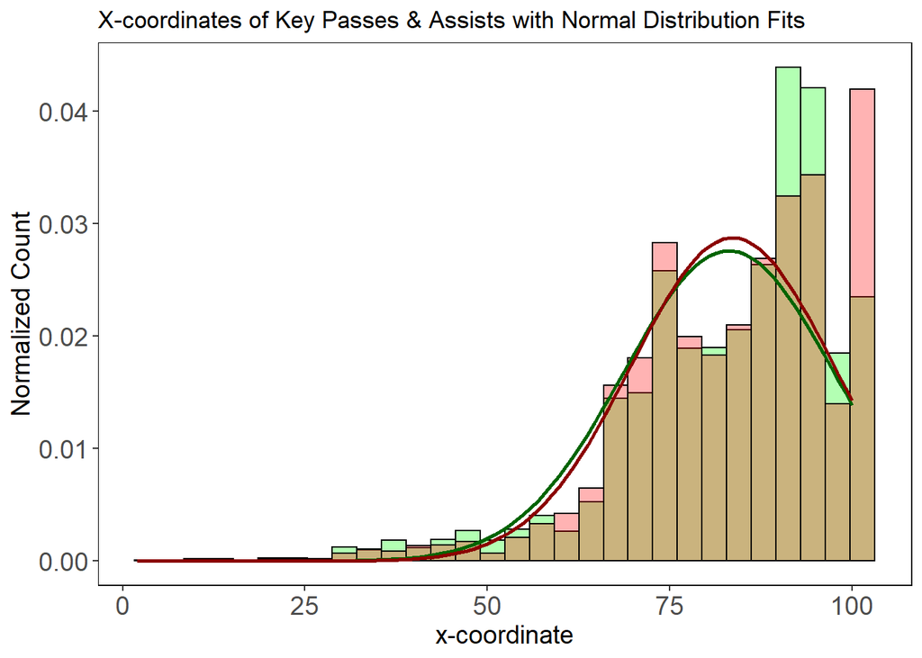

```r
#Histograms of Assist and Key Pass x Coordinates

ggplot()+
  geom_histogram(data=(assists_clean), aes(x=x.Start, y=..density..), color='Black', fill='Green', alpha=0.3)+

  geom_histogram(data=(key_passes_clean), aes(x=x.Start, y=..density..), color='Black', fill='Red', alpha=0.3)+

  stat_function(fun = dnorm, args = list(mean = mean(assists_clean$x.Start), sd = sd(assists_clean$x.Start)), color='dark green', fill='green', size=1)+

  stat_function(fun = dnorm, args = list(mean = mean(key_passes_clean$x.Start), sd = sd(key_passes_clean$x.Start)), color='dark red', fill='red', size=1)+

  labs(title="X-coordinates of Key Passes & Assists with Normal Distribution Fits", x="x-coordinate", y="Normalized Count")+

  scale_color_manual(name='Key',values=c('Green', 'Red'), labels=c('Assists','Key Passes'))+
  theme(panel.background = element_blank(),
        panel.border=element_rect(color='black', fill=NA),
        axis.text = element_text(size=14),
        axis.title = element_text(size=14))
```

```r
ggsave("assist_keypass_x.jpeg")
```

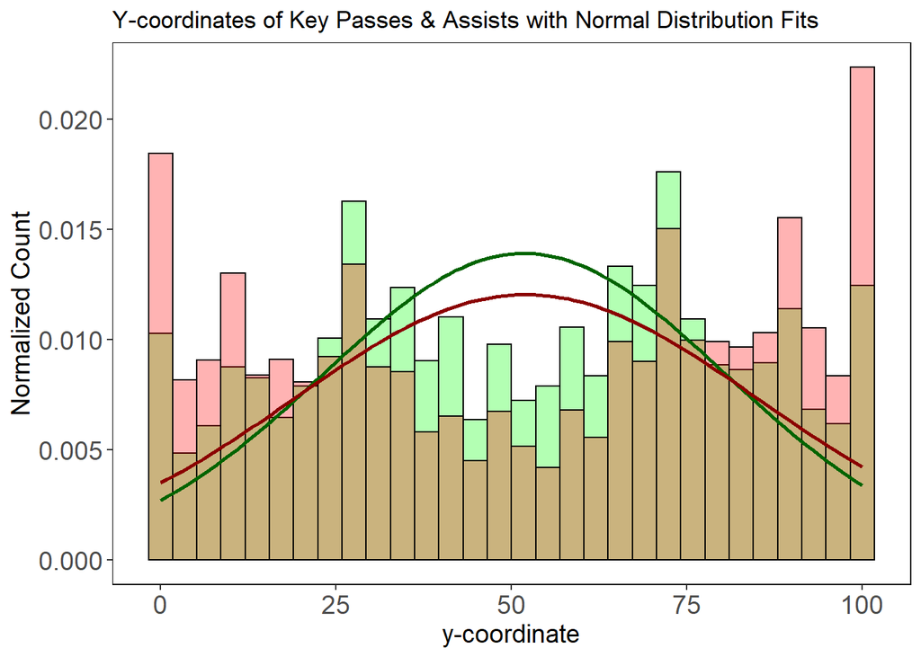

```r
#Histograms of Assist and Key Pass y Coordinates

ggplot()+
  geom_histogram(data=(assists_clean), aes(x=y.Start, y=..density..), color='Black', fill='Green', alpha=0.3)+

  geom_histogram(data=(key_passes_clean), aes(x=y.Start, y=..density..), color='Black', fill='Red', alpha=0.3)+

  stat_function(fun = dnorm, args = list(mean = mean(assists_clean$y.Start), sd = sd(assists_clean$y.Start)), color='dark green', fill='green', size=1)+

  stat_function(fun = dnorm, args = list(mean = mean(key_passes_clean$y.Start), sd = sd(key_passes_clean$y.Start)), color='dark red', fill='red', size=1)+

  labs(title="Y-coordinates of Key Passes & Assists with Normal Distribution Fits", x="y-coordinate", y="Normalized Count")+

  scale_color_manual(name='Key',values=c('Green', 'Red'), labels=c('Assists','Key Passes'))+
  theme(panel.background = element_blank(),
        panel.border=element_rect(color='black', fill=NA),
        axis.text = element_text(size=14),
        axis.title = element_text(size=14))
```

```r
ggsave("assist_keypass_y.jpeg")
```

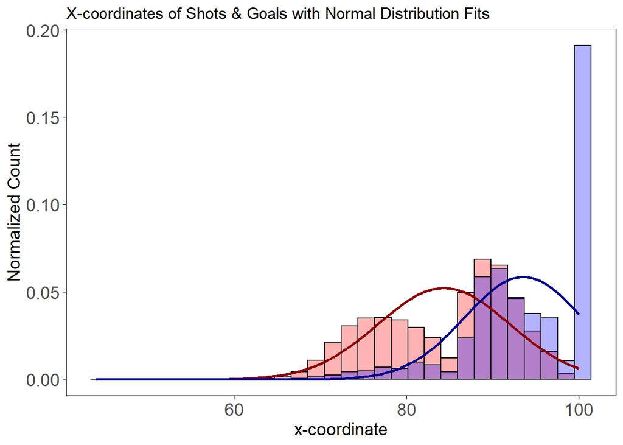

```r
#Histograms of shots and goals x coordinates

ggplot()+
  geom_histogram(data=(shots_clean), aes(x=x.Start, y=..density..), color='Black', fill='Red', alpha=0.3)+

  geom_histogram(data=(goals_clean), aes(x=x.Start, y=..density..), color='Black', fill='Blue', alpha=0.3)+

  stat_function(fun = dnorm, args = list(mean = mean(shots_clean$x.Start), sd = sd(shots_clean$x.Start)), color='dark red', fill='red', size=1)+

  stat_function(fun = dnorm, args = list(mean = mean(goals_clean$x.Start), sd = sd(goals_clean$x.Start)), color='dark blue', fill='blue', size=1)+

  labs(title="X-coordinates of Shots & Goals with Normal Distribution Fits", x="x-coordinate", y="Normalized Count")+

  scale_color_manual(name='Key',values=c('Blue', 'Red'), labels=c('Goals','Shots'))+
  theme(panel.background = element_blank(),
        panel.border=element_rect(color='black', fill=NA),
        axis.text = element_text(size=14),
        axis.title = element_text(size=14))
```

```r
ggsave("shots_goals_x.jpeg")
```

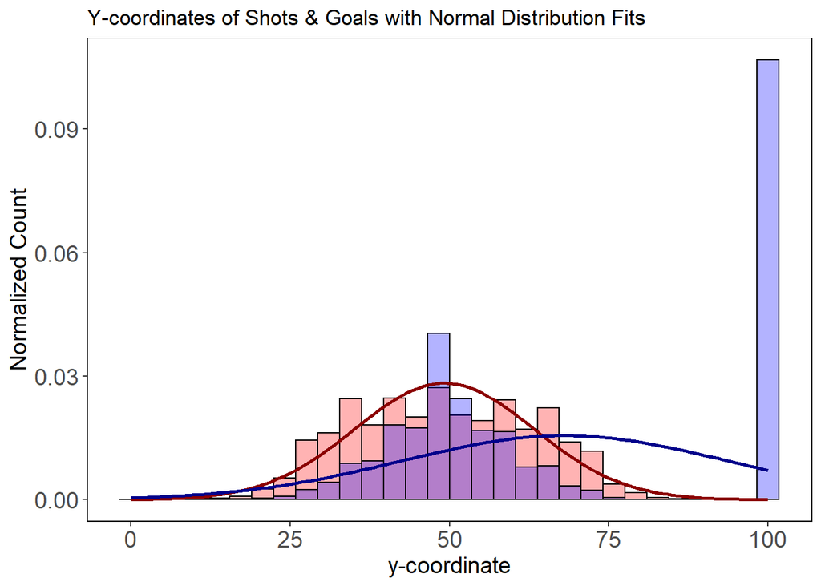

```r
#Histograms of shots and goals y coordinates

ggplot()+
  geom_histogram(data=shots_clean, aes(x=y.Start, y=..density..), color='Black', fill='Red', alpha=0.3)+

  geom_histogram(data=goals_clean, aes(x=y.Start, y=..density..), color='Black', fill='Blue', alpha=0.3)+

  stat_function(fun = dnorm, args = list(mean = mean(shots_clean$y.Start), sd = sd(shots_clean$y.Start)), color='dark red', fill='red', size=1)+

  stat_function(fun = dnorm, args = list(mean = mean(goals_clean$y.Start), sd = sd(goals_clean$y.Start)), color='dark blue', fill='blue', size=1)+

  labs(title="Y-coordinates of Shots & Goals with Normal Distribution Fits", x="y-coordinate", y="Normalized Count")+

  scale_color_manual(name='Key',values=c('Blue', 'Red'), labels=c('Goals','Shots'))+
  theme(panel.background = element_blank(),
        panel.border=element_rect(color='black', fill=NA),
        axis.text = element_text(size=14),
        axis.title = element_text(size=14))
```

```r
ggsave("shots_goals_y.jpeg")
```

Upon reviewing the plots, it appears that there are some differences between some variables. We will continue by performing some hypothesis tests.

```r
#Distance

ttest_assist_v_keypass_dist <- t.test(assists_clean$dist, key_passes_clean$dist)

capture.output(ttest_assist_v_keypass_dist, file = "ttests.txt", append = T)

ttest_goals_v_shots_dist <- t.test(goals_clean$dist, shots_clean$dist)

capture.output(ttest_goals_v_shots_dist, file = "ttests.txt", append = T)

#Starting X-coordinate

ttest_assist_v_keypass_x <- t.test(assists_clean_x$x.Start, key_passes_clean_x$x.Start)

capture.output(ttest_assist_v_keypass_x, file = "ttests.txt", append = T)

ttest_goals_v_shots_x <- t.test(goals_clean$x.Start, shots_clean$x.Start)

capture.output(ttest_goals_v_shots_x, file = "ttests.txt", append = T)

#Starting Y-coordinate

ttest_assist_v_keypass_y <- t.test(assists_clean_y$y.Start, key_passes_clean_y$y.Start)

capture.output(ttest_assist_v_keypass_y, file = "ttests.txt", append = T)

ttest_goals_v_shots_y <- t.test(goals_clean$y.Start, shots_clean$y.Start)

capture.output(ttest_goals_v_shots_y, file = "ttests.txt", append = T)
```

1. Assist v. Key Pass Distance (higher mean for key pass)
2. Goal v. Shot Distance (higher mean for goals)
3. Goal v. Shot x.Start (higher mean for goals)
4. Goal v. Shot y.Start (higher mean for goals)

Based on this finding, it must be the case that teams consider strategies such as planning their starting points or practicing the accuracy of their shots in order to cover a desirable distance.

Regardless of the result (goal v shot, assist v key pass), how do each team’s distance and starting points compare to other teams? Let’s take a look at the World Cup in particular.

```r
# Stack assist and key pass dataset

assist_key_pass <-rbind(assists_clean, key_passes_clean)
assist_key_pass_wc <- subset(assist_key_pass, competition=="World Cup")

str(assist_key_pass_wc)
head(assist_key_pass_wc)

# Focus on top 5 teams with most assists + key passes
freq1 <- sort(table(assist_key_pass_wc$Team.Name),decreasing=T)
print(freq1)

assist_key_pass_wc_top5 <- subset(assist_key_pass_wc, Team.Name == "Belgium" | Team.Name == "England" | Team.Name == "Croatia" | Team.Name == "Brazil" | Team.Name == "France")

jpeg(file="assist_key_pass_wc_dist.jpeg")
boxplot(assist_key_pass_wc_top5$dist ~ assist_key_pass_wc_top5$Team.Name, main = "Assist or Key Pass Distance by Team", ylab = "Distance", xlab = "Team")
dev.off()

# Stack shot and goal dataset

shots_goals <-rbind(shots_clean, goals_clean)
shots_goals_wc <- subset(shots_goals, competition=="World Cup")

str(shots_goals_wc)
head(shots_goals_wc)

# Focus on top 5 teams with most goals + shots
freq2 <- sort(table(shots_goals_wc$Team.Name),decreasing=T)
print(freq2)

shots_goals_wc_top5 <- subset(shots_goals_wc, Team.Name == "Belgium" | Team.Name == "England" | Team.Name == "Croatia" | Team.Name == "Brazil" | Team.Name == "France")

jpeg(file="shots_goals_wc_dist.jpeg")
boxplot(shots_goals_wc_top5$dist ~ shots_goals_wc_top5$Team.Name, main = "Shot or Goal Distance by Team", ylab = "Distance", xlab = "Team")
dev.off()

jpeg(file="shots_goals_wc_x.jpeg")
boxplot(shots_goals_wc_top5$x.Start ~ shots_goals_wc_top5$Team.Name, main = "X.Start by Team", ylab = "X.Start", xlab = "Team")
dev.off()

jpeg(file="shots_goals_wc_y.jpeg")
boxplot(shots_goals_wc_top5$y.Start ~ shots_goals_wc_top5$Team.Name, main = "Y.Start by Team", ylab = "Y.Start", xlab = "Team")
dev.off()
```

The plots show some differences among teams. We continue by looking at these differences using an anova test.

```r
# install.packages("rstatix")
library(rstatix)

# Assist and Key Pass Distance
assist_key_pass_dist <- assist_key_pass_wc_top5 %>% anova_test(dist ~ Team.Name)

capture.output(assist_key_pass_dist, file = "anova.txt", append = T)

# Shots and Goals Distance
shots_goals_dist <- shots_goals_wc_top5 %>% anova_test(dist ~ Team.Name)

capture.output(shots_goals_dist, file = "anova.txt", append = T)

# Shots and Goals X.Start
shots_goals_x <- shots_goals_wc_top5 %>% anova_test(x.Start ~ Team.Name)

capture.output(shots_goals_x, file = "anova.txt", append = T)

# Shots and Goals Y.Start
shots_goals_y <- shots_goals_wc_top5 %>% anova_test(y.Start ~ Team.Name)

capture.output(shots_goals_y, file = "anova.txt", append = T)
```

1. Shots + Goals Distance
2. Shots + Goals Y.Start

Concluding Statement: Based on t-tests done between Shots vs Goals, and Assists vs Key Passes, there is evidence of distance and start coordinate differences between successful and unsuccessful plays. Applying this finding to the top 5 teams in the World Cup, we see further that there are teams that are significantly different in their tendencies for distance and Y.Start when it comes to attempting a goal.